# Why some people write very long product reviews ?

## by (Alaaeldin Zaky)

## Investigation Overview

> In product reviewing, you would find very long product reviews. What causes some text reviews to be much longer than others ? Are positive reviews usually longer? Are there some special product categories/brands that affect the length of the reviews ? These questions we are going to address in this investigation.

## Dataset Overview

> This dataset consists of a list of over 71,045 reviews from 1,000 different products provided by Datafiniti's Product Database. The dataset includes the text and title of the review, the name and manufacturer of the product, reviewer metadata, and more.

## Distribution of Product Rating

> This count plot shows the distribution of star ratings for the products in this dataset. As shown the data is imbalanced, as most of the rating reviews are positive reviews.

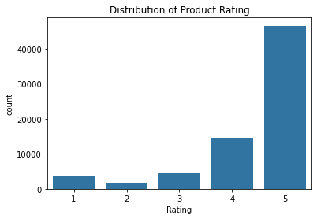

## Distribution of Product Category

> After doing some manipulation and feature enginnering to the dataset, the count plot for the product categories is plotted. The distribution shows that the dataset is concerned on some categories like movies and household essentials a lot more than other categories like food and kitchen & Dining.

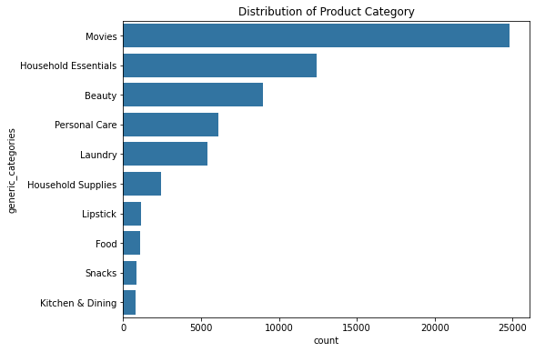

## Distribution of Text Review Length

> Text review length in the dataset take on a very large range of values, from about 5 characters at the lowest, to more than 3000 charachters at the highest. Plotted on a logarithmic scale, the histogram of text reviews length of takes on a bimodal shape.

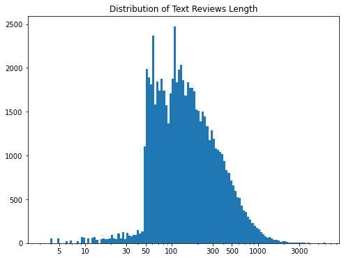

## Text review length vs. Rating

> To get some insight about what are the factors for long text reviews, the box plot for the text review length is plotted versus all star rating levels. It could be observed that negative reviews tend to have a longer text reviews.

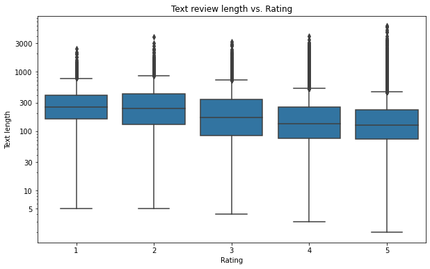

## Text Review Length vs. different Categories

> To get more insight about our main feature, the box plot for the text review length is plotted versus different product categories. From this plot it could be observed that some categories such as beauty and home, personal care and home products tend to have a longer text reviews than other categories such as food and snacks.

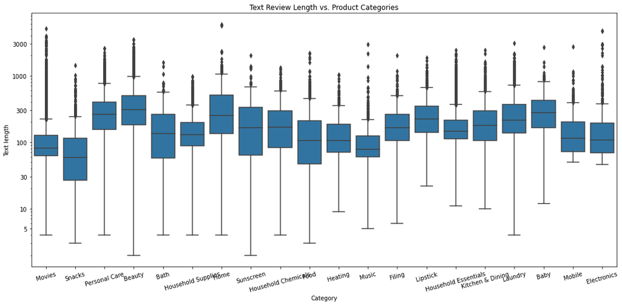

## Text Review Length by Rating and Product Categories

> To have a good overview and a better understanding for our features, the distribution of the text review length is plotted for each star rating and for each category.

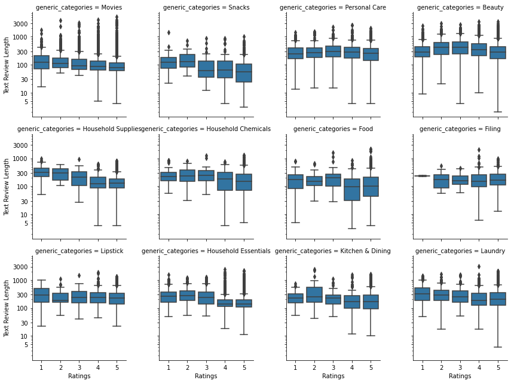

## Conclsuion

> From the previous analysis and those visulaizations, it could be concluded that generally people tend to write longer reviews when they are mad or dislike the product they bought so they would be more frustrated and have the motive to write more details about the review. This also tends to happen with some categories related to beauty and personal care more than movies and food.